# Tenfold Symmetry Classification

The article is devoted to an elementary summary of Tenfold Symmetry Classification.

For noninteracting system of electrons, all possible symmetry classes can be systematically enumerated in term of the specific characteristic after implementing discrte symmtries on the Hamiltonian following Altland and Zirnbauer.

We will resort the second quantized Hamiltonian to describe the noninteracting system as the general form:

\begin{equation}\label{T.1} \hat{H}=\hat{\psi}^{\dagger}_{I} H^{I J} \hat{\psi}_{J}=\hat{\psi}^{\dagger} H \hat{\psi} \end{equation}

#### Wigner--- Symmetry Representation Theorem

Any symmetry transformation in quantum mechanics can be represented on the Hilbert space by an operator that is either linear and unitary,or antilinear and antiunitary.

When we implement some specific symmetry transformation on the system, we declare the system is symmetry invarianrt if the canonical anticommutation relation and $\hat{H}$ is preserved, as following. \begin{align} &\hat{\psi}_{I} \longmapsto \hat{\psi}^{\prime}_{I} := \hat{U} \hat{\psi}_{I} \hat{U}^{\dagger} = U^{J}_{I} \hat{\psi}_{J}\\ &\{\hat{\psi}_{I},\hat{\psi}^{\dagger}_{J}\}=\hat{U} \{\hat{\psi}_{I},\hat{\psi}^{\dagger}_{J}\} \hat{U}^{\dagger} \text{and,} \hat{H}= \hat{U} \hat{H} \hat{U}^{\dagger} \end{align}

We must be warned the confusion that here only $\hat{\psi} and \hat{H}$ are operators rather the matrix H. The next crucial technique transfer the symmetry of the system to the manifestation of matrix H. More explicitly, we narrow the concentration on relationship between the H and its three entries reads $-H ,H^T and H ^{*} $. We next elaborate on with the familiar time reversal symmetry.

#### Time Reversal Symmetry

Antiunitary symmetry

\begin{align} &\hat{T} \hat{\psi}_{I} \hat{T}^{\dagger} = ({U_{T}})^{J}_{I} \hat{\psi}_{J}\\ &\hat{H}= \hat{T} \hat{H} \hat{T}^{\dagger}\\ &\hat{H}= \hat{T} \hat{H} \hat{T}^{\dagger}= \hat{T}\hat{\psi}^{\dagger} H \hat{\psi} \hat{T}^{\dagger}=\hat{T}\hat{\psi}^{\dagger} \hat{T}^{\dagger} \hat{T} H \hat{\psi} \hat{T}^{\dagger}\\ &=\hat{T}\hat{\psi}^{\dagger} \hat{T}^{\dagger} H^{*} \hat{T}\hat{\psi} \hat{T}^{\dagger}\\ &=\hat{\psi}^{\dagger} U^{\dagger}_{T} H^{*} U_{T} \hat{\psi}\\ &\text {compared with ,}\\ &\hat{H}=\hat{\psi}^{\dagger}_{I} H^{I J} \hat{\psi}_{J}=\hat{\psi}^{\dagger} H \hat{\psi} \end{align}

Now we arrive at the exactly equivalent approach to describe the time reversal symmetry by means of the matix H.

\begin{equation}\label{key} \hat{T}:U^{\dagger}_{T} H^{*} U_{T}=+H \end{equation}

Let's go further to explore the property of time reversal symmetry by applying the tansformation twice, we obtain the identity.

\begin{align} \hat{T} \hat{T} \hat{H} \hat{T}^{\dagger}\hat{T}^{\dagger} &=\hat{T} \hat{\psi}^{\dagger} U^{\dagger}_{T} H^{*} U_{T} \hat{\psi} \hat{T}^{\dagger} \\ &=\hat{T} \hat{\psi}^{\dagger} \hat{T}^{\dagger} \hat{T}U^{\dagger}_{T} H^{*} U_{T} \hat{\psi} \hat{T}^{\dagger}\\ &=\hat{T} \hat{\psi}^{\dagger} \hat{T}^{\dagger}( U^{\dagger}_{T} H^{*} U_{T} )^{*}\hat{T} \hat{\psi} \hat{T}^{\dagger} \\ &=\hat{\psi}^{\dagger} U^{\dagger}_{T}( U^{\dagger}_{T} H^{*} U_{T} )^{*} U_{T} \hat{\psi}\\ &=\hat{\psi}^{\dagger} (U^{*}_{T}U_{T})^{\dagger} H (U^{*}_{T}U_{T}) \hat{\psi} \end{align}\begin{equation}\label{t.4} (U^{*}_{T}U_{T})^{\dagger} H (U^{*}_{T}U_{T})=H \end{equation}

This implies immediately that $U^{*}_{T}U_{T}=e^{i\alpha}I$ . We then extract some insightful results by some easy operations.

\begin{align} &U^{*}_{T}U_{T}=e^{i\alpha}I \longmapsto U^{*}_{T}=e^{i\alpha} U^{\dagger}_{T} \longmapsto (U_{T})^{T}=e^{i\alpha} U_{T}\\ &((U_{T})^{T})^{T}=(e^{i\alpha} U_{T})^{T}=e^{i2\cdot \alpha} U_{T}\\ &e^{i2\cdot \alpha}=1 \end{align}

There leads to two possibilities $U^{*}_{T}U_{T}=\pm 1$. Thus acting on a fermion operator $\hat{\psi}$ with $\hat{T}^2$ simply reproduce $\hat{\psi}$, possibly up to a opposite sign $\hat{T}^2 \hat{\psi} \hat{T}^{-2}=(U^{*}_{T}U_{T}) \hat{\psi}=\pm \hat{\psi}$.

It is crucial to realize that for an operator consisting of n fermion field operators (creation and annihilation ), the acting of $\hat{T}^2$ gives $\hat{T}^2 \hat{A} \hat{T}^{-2} = (-1)^n \hat{A}$. Then the familiar Kramer degeneration comes in its unique way.

To summarize,for time reversal symmetry:

$\hat{T}:H=+U^{\dagger}_{T} H^{*} U_{T}, U_{T}U^{\dagger}_{T}=1,(U_{T})^{T}=\pm U_{T} $

### Formal routine to symmetry

Now its time to go beyond the scope of TRS and extend our sight to other discrete symmetry.

$\varTheta$ symmetry : $\hat{T}:H=+U^{\dagger}_{\varTheta} H^{*} U_{\varTheta}, (U_{\varTheta})^{T}=\pm U_{\varTheta} $

$\Xi$ symmetry : $\hat{\Xi}:H=-U^{\dagger}_{\Xi } H^{T} U_{\Xi }, (U_{\Xi})^{T}=\pm U_{\Xi} $

P symmetry : $\hat{\varTheta}:H=-U^{\dagger}_{ \varTheta} H U_{\varTheta }$

Where T,C and P symmetry correspond separately to time reversal symmtry, particle-hole symmetry and chirality symmetry.

It seems a infinite long way to get a deeply insightful understanding towards the symmetry.

Idled away a day!!!

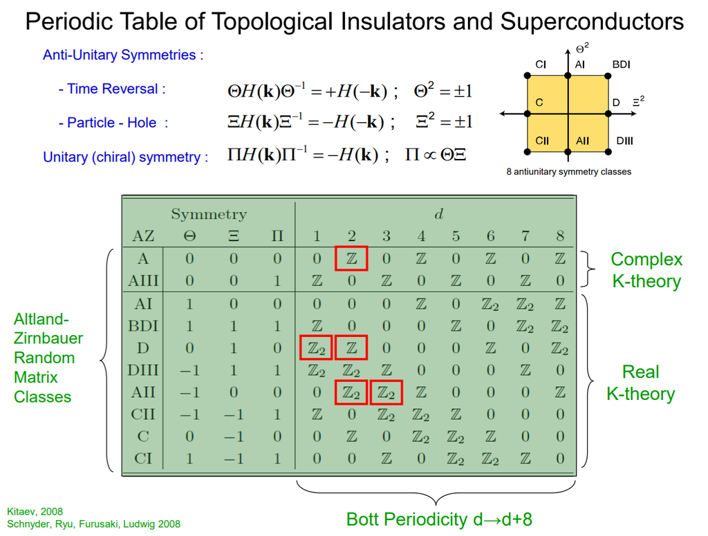